# Predicting customers that might default the credit payment in the next month

Kalpa Subbaiah,Supratim Chaudhuri,Sasi Kumar

18 August 2017

**NOTE** clear the environment

```r
rm(list = ls(all=TRUE))
```

# Reading & Understanding the Data

- The data depicts the cases of customers’ default payments in Taiwan. Given the general information, past payment history and bill history of customers, the task is to predict customers that might default the credit payment in the next month
- The dataset has 30000 rows and 25 columns.
- The column/variable names’ explanation is given below:
1. **LIMIT_BAL:** Amount of the given credit (NT dollar): it includes both the individual consumer credit and his/her family (supplementary) credit.
2. **SEX :** Gender (1 = male; 2 = female).
3. **EDUCATION :** Education (1 = graduate school; 2 = university; 3 = high school; 4 = others).
4. **MARRIAGE :**_ Marital status (1 = married; 2 = single; 3 = others).
5. **AGE :** Age (year).
6. **PAY_0 to PAY_6 :** History of past payment.
7. **BILL_AMT1 to BILL_AMT6 :** Amount of bill statement (NT dollar).
8. **PAY_AMT1 to PAY_AMT6 :** Amount of previous payment (NT dollar).
9. **default.payment.next.month :** Target variable (0 or 1- will the customer make the credit payment next month or not)

```r
setwd("C:/insofe\\cute_2\\final")
getwd()
```

```
## [1] "C:/insofe/cute_2/final"
```

```r
defaulters_data <- read.csv("CreditCard_Defaulters.csv", header=T)
names(defaulters_data)
```

```
##  [1] "ï..ID"                      "LIMIT_BAL"
##  [3] "SEX"                        "EDUCATION"
##  [5] "MARRIAGE"                   "AGE"
##  [7] "PAY_0"                      "PAY_2"
##  [9] "PAY_3"                      "PAY_4"
## [11] "PAY_5"                      "PAY_6"
## [13] "BILL_AMT1"                  "BILL_AMT2"
## [15] "BILL_AMT3"                  "BILL_AMT4"
## [17] "BILL_AMT5"                  "BILL_AMT6"
## [19] "PAY_AMT1"                   "PAY_AMT2"
## [21] "PAY_AMT3"                   "PAY_AMT4"
## [23] "PAY_AMT5"                   "PAY_AMT6"
## [25] "default.payment.next.month"
```

- Using the str() and summary() function to get a feel for the dataset.

```r
str(defaulters_data)
```

```
## 'data.frame':    30000 obs. of  25 variables:
##  $ ï..ID                     : int  1 2 3 4 5 6 7 8 9 10 ...
##  $ LIMIT_BAL                 : int  20000 120000 90000 50000 50000 50000 500000 100000 140000 20000 ...
##  $ SEX                       : int  2 2 2 2 1 1 1 2 2 1 ...
##  $ EDUCATION                 : int  2 2 2 2 2 1 1 2 3 3 ...
##  $ MARRIAGE                  : int  1 2 2 1 1 2 2 2 1 2 ...
##  $ AGE                       : int  24 26 34 37 57 37 29 23 28 35 ...
##  $ PAY_0                     : int  2 -1 0 0 -1 0 0 0 0 -2 ...
##  $ PAY_2                     : int  2 2 0 0 0 0 0 -1 0 -2 ...
##  $ PAY_3                     : int  -1 0 0 0 -1 0 0 -1 2 -2 ...
##  $ PAY_4                     : int  -1 0 0 0 0 0 0 0 0 -2 ...
##  $ PAY_5                     : int  -2 0 0 0 0 0 0 0 0 -1 ...
##  $ PAY_6                     : int  -2 2 0 0 0 0 0 -1 0 -1 ...
##  $ BILL_AMT1                 : int  3913 2682 29239 46990 8617 64400 367965 11876 11285 0 ...
##  $ BILL_AMT2                 : int  3102 1725 14027 48233 5670 57069 412023 380 14096 0 ...
##  $ BILL_AMT3                 : int  689 2682 13559 49291 35835 57608 445007 601 12108 0 ...
##  $ BILL_AMT4                 : int  0 3272 14331 28314 20940 19394 542653 221 12211 0 ...
##  $ BILL_AMT5                 : int  0 3455 14948 28959 19146 19619 483003 -159 11793 13007 ...
##  $ BILL_AMT6                 : int  0 3261 15549 29547 19131 20024 473944 567 3719 13912 ...
##  $ PAY_AMT1                  : int  0 0 1518 2000 2000 2500 55000 380 3329 0 ...
##  $ PAY_AMT2                  : int  689 1000 1500 2019 36681 1815 40000 601 0 0 ...
##  $ PAY_AMT3                  : int  0 1000 1000 1200 10000 657 38000 0 432 0 ...
##  $ PAY_AMT4                  : int  0 1000 1000 1100 9000 1000 20239 581 1000 13007 ...
##  $ PAY_AMT5                  : int  0 0 1000 1069 689 1000 13750 1687 1000 1122 ...
##  $ PAY_AMT6                  : int  0 2000 5000 1000 679 800 13770 1542 1000 0 ...
##  $ default.payment.next.month: int  1 1 0 0 0 0 0 0 0 0 ...
```

```r
summary(defaulters_data)
```

```
##      ï..ID         LIMIT_BAL            SEX          EDUCATION
##  Min.   :    1   Min.   :  10000   Min.   :1.000   Min.   :0.000
##  1st Qu.: 7501   1st Qu.:  50000   1st Qu.:1.000   1st Qu.:1.000
##  Median :15000   Median : 140000   Median :2.000   Median :2.000
##  Mean   :15000   Mean   : 167484   Mean   :1.604   Mean   :1.853
##  3rd Qu.:22500   3rd Qu.: 240000   3rd Qu.:2.000   3rd Qu.:2.000
##  Max.   :30000   Max.   :1000000   Max.   :2.000   Max.   :6.000
##     MARRIAGE          AGE            PAY_0             PAY_2
##  Min.   :0.000   Min.   :21.00   Min.   :-2.0000   Min.   :-2.0000
##  1st Qu.:1.000   1st Qu.:28.00   1st Qu.:-1.0000   1st Qu.:-1.0000
##  Median :2.000   Median :34.00   Median : 0.0000   Median : 0.0000
##  Mean   :1.552   Mean   :35.49   Mean   :-0.0167   Mean   :-0.1338
##  3rd Qu.:2.000   3rd Qu.:41.00   3rd Qu.: 0.0000   3rd Qu.: 0.0000
##  Max.   :3.000   Max.   :79.00   Max.   : 8.0000   Max.   : 8.0000
##      PAY_3             PAY_4             PAY_5             PAY_6
##  Min.   :-2.0000   Min.   :-2.0000   Min.   :-2.0000   Min.   :-2.0000
##  1st Qu.:-1.0000   1st Qu.:-1.0000   1st Qu.:-1.0000   1st Qu.:-1.0000
##  Median : 0.0000   Median : 0.0000   Median : 0.0000   Median : 0.0000
##  Mean   :-0.1662   Mean   :-0.2207   Mean   :-0.2662   Mean   :-0.2911
##  3rd Qu.: 0.0000   3rd Qu.: 0.0000   3rd Qu.: 0.0000   3rd Qu.: 0.0000
##  Max.   : 8.0000   Max.   : 8.0000   Max.   : 8.0000   Max.   : 8.0000
##    BILL_AMT1         BILL_AMT2        BILL_AMT3         BILL_AMT4
##  Min.   :-165580   Min.   :-69777   Min.   :-157264   Min.   :-170000
##  1st Qu.:   3559   1st Qu.:  2985   1st Qu.:   2666   1st Qu.:   2327
##  Median :  22382   Median : 21200   Median :  20089   Median :  19052
##  Mean   :  51223   Mean   : 49179   Mean   :  47013   Mean   :  43263
##  3rd Qu.:  67091   3rd Qu.: 64006   3rd Qu.:  60165   3rd Qu.:  54506
##  Max.   : 964511   Max.   :983931   Max.   :1664089   Max.   : 891586
##    BILL_AMT5        BILL_AMT6          PAY_AMT1         PAY_AMT2
##  Min.   :-81334   Min.   :-339603   Min.   :     0   Min.   :      0
##  1st Qu.:  1763   1st Qu.:   1256   1st Qu.:  1000   1st Qu.:    833
##  Median : 18105   Median :  17071   Median :  2100   Median :   2009
##  Mean   : 40311   Mean   :  38872   Mean   :  5664   Mean   :   5921
##  3rd Qu.: 50191   3rd Qu.:  49198   3rd Qu.:  5006   3rd Qu.:   5000
##  Max.   :927171   Max.   : 961664   Max.   :873552   Max.   :1684259
##     PAY_AMT3         PAY_AMT4         PAY_AMT5           PAY_AMT6
##  Min.   :     0   Min.   :     0   Min.   :     0.0   Min.   :     0.0
##  1st Qu.:   390   1st Qu.:   296   1st Qu.:   252.5   1st Qu.:   117.8
##  Median :  1800   Median :  1500   Median :  1500.0   Median :  1500.0
##  Mean   :  5226   Mean   :  4826   Mean   :  4799.4   Mean   :  5215.5
##  3rd Qu.:  4505   3rd Qu.:  4013   3rd Qu.:  4031.5   3rd Qu.:  4000.0
##  Max.   :896040   Max.   :621000   Max.   :426529.0   Max.   :528666.0
##  default.payment.next.month
##  Min.   :0.0000
##  1st Qu.:0.0000
##  Median :0.0000
##  Mean   :0.2212
##  3rd Qu.:0.0000
##  Max.   :1.0000
```

- Take a look at the data using the “head()” and “tail()” functions

```r
head(defaulters_data)
```

```
##   ï..ID LIMIT_BAL SEX EDUCATION MARRIAGE AGE PAY_0 PAY_2 PAY_3 PAY_4 PAY_5
## 1     1     20000   2         2        1  24     2     2    -1    -1    -2
## 2     2    120000   2         2        2  26    -1     2     0     0     0
## 3     3     90000   2         2        2  34     0     0     0     0     0
## 4     4     50000   2         2        1  37     0     0     0     0     0
## 5     5     50000   1         2        1  57    -1     0    -1     0     0
## 6     6     50000   1         1        2  37     0     0     0     0     0
##   PAY_6 BILL_AMT1 BILL_AMT2 BILL_AMT3 BILL_AMT4 BILL_AMT5 BILL_AMT6
## 1    -2      3913      3102       689         0         0         0
## 2     2      2682      1725      2682      3272      3455      3261
## 3     0     29239     14027     13559     14331     14948     15549
## 4     0     46990     48233     49291     28314     28959     29547
## 5     0      8617      5670     35835     20940     19146     19131
## 6     0     64400     57069     57608     19394     19619     20024
##   PAY_AMT1 PAY_AMT2 PAY_AMT3 PAY_AMT4 PAY_AMT5 PAY_AMT6
## 1        0      689        0        0        0        0
## 2        0     1000     1000     1000        0     2000
## 3     1518     1500     1000     1000     1000     5000
## 4     2000     2019     1200     1100     1069     1000
## 5     2000    36681    10000     9000      689      679
## 6     2500     1815      657     1000     1000      800
##   default.payment.next.month
## 1                          1
## 2                          1
## 3                          0
## 4                          0
## 5                          0
## 6                          0
```

```r
tail(defaulters_data)
```

```
##       ï..ID LIMIT_BAL SEX EDUCATION MARRIAGE AGE PAY_0 PAY_2 PAY_3 PAY_4
## 29995 29995     80000   1         2        2  34     2     2     2     2
## 29996 29996    220000   1         3        1  39     0     0     0     0
## 29997 29997    150000   1         3        2  43    -1    -1    -1    -1
## 29998 29998     30000   1         2        2  37     4     3     2    -1
## 29999 29999     80000   1         3        1  41     1    -1     0     0
## 30000 30000     50000   1         2        1  46     0     0     0     0
##       PAY_5 PAY_6 BILL_AMT1 BILL_AMT2 BILL_AMT3 BILL_AMT4 BILL_AMT5
## 29995     2     2     72557     77708     79384     77519     82607
## 29996     0     0    188948    192815    208365     88004     31237
## 29997     0     0      1683      1828      3502      8979      5190
## 29998     0     0      3565      3356      2758     20878     20582
## 29999     0    -1     -1645     78379     76304     52774     11855
## 30000     0     0     47929     48905     49764     36535     32428
##       BILL_AMT6 PAY_AMT1 PAY_AMT2 PAY_AMT3 PAY_AMT4 PAY_AMT5 PAY_AMT6
## 29995     81158     7000     3500        0     7000        0     4000
## 29996     15980     8500    20000     5003     3047     5000     1000
## 29997         0     1837     3526     8998      129        0        0
## 29998     19357        0        0    22000     4200     2000     3100
## 29999     48944    85900     3409     1178     1926    52964     1804
## 30000     15313     2078     1800     1430     1000     1000     1000
##       default.payment.next.month
## 29995                          1
## 29996                          0
## 29997                          0
## 29998                          1
## 29999                          1
## 30000                          1
```

# Data Pre-processing

- Are there any missing values in the dataset?

```r
sum(is.na(defaulters_data))
```

```
## [1] 0
```

- Change the data types of columns sex,education,marriage and default payment to factors

```r
cat_var= c("SEX","EDUCATION","MARRIAGE","PAY_0","PAY_2","PAY_3","PAY_4","PAY_5","PAY_6","default.payment.next.month")
num_var= setdiff(names(defaulters_data),cat_var)
defaulters_data[,cat_var]= data.frame(apply(defaulters_data[,cat_var],2,function(x) as.factor(as.character(x))))
defaulters_data[,num_var]= data.frame(apply(defaulters_data[,num_var],2,function(x) as.numeric((x))))
str(defaulters_data)
```

```
## 'data.frame':    30000 obs. of  25 variables:
##  $ ï..ID                     : num  1 2 3 4 5 6 7 8 9 10 ...
##  $ LIMIT_BAL                 : num  20000 120000 90000 50000 50000 50000 500000 100000 140000 20000 ...
##  $ SEX                       : Factor w/ 2 levels "1","2": 2 2 2 2 1 1 1 2 2 1 ...
##  $ EDUCATION                 : Factor w/ 7 levels "0","1","2","3",..: 3 3 3 3 3 2 2 3 4 4 ...
##  $ MARRIAGE                  : Factor w/ 4 levels "0","1","2","3": 2 3 3 2 2 3 3 3 2 3 ...
##  $ AGE                       : num  24 26 34 37 57 37 29 23 28 35 ...
##  $ PAY_0                     : Factor w/ 11 levels "-1","-2","0",..: 5 1 3 3 1 3 3 3 3 2 ...
##  $ PAY_2                     : Factor w/ 11 levels "-1","-2","0",..: 5 5 3 3 3 3 3 1 3 2 ...
##  $ PAY_3                     : Factor w/ 11 levels "-1","-2","0",..: 1 3 3 3 1 3 3 1 5 2 ...
##  $ PAY_4                     : Factor w/ 11 levels "-1","-2","0",..: 1 3 3 3 3 3 3 3 3 2 ...
##  $ PAY_5                     : Factor w/ 10 levels "-1","-2","0",..: 2 3 3 3 3 3 3 3 3 1 ...
##  $ PAY_6                     : Factor w/ 10 levels "-1","-2","0",..: 2 4 3 3 3 3 3 1 3 1 ...
##  $ BILL_AMT1                 : num  3913 2682 29239 46990 8617 ...
##  $ BILL_AMT2                 : num  3102 1725 14027 48233 5670 ...
##  $ BILL_AMT3                 : num  689 2682 13559 49291 35835 ...
##  $ BILL_AMT4                 : num  0 3272 14331 28314 20940 ...
##  $ BILL_AMT5                 : num  0 3455 14948 28959 19146 ...
##  $ BILL_AMT6                 : num  0 3261 15549 29547 19131 ...
##  $ PAY_AMT1                  : num  0 0 1518 2000 2000 ...
##  $ PAY_AMT2                  : num  689 1000 1500 2019 36681 ...
##  $ PAY_AMT3                  : num  0 1000 1000 1200 10000 657 38000 0 432 0 ...
##  $ PAY_AMT4                  : num  0 1000 1000 1100 9000 ...
##  $ PAY_AMT5                  : num  0 0 1000 1069 689 ...
##  $ PAY_AMT6                  : num  0 2000 5000 1000 679 ...
##  $ default.payment.next.month: Factor w/ 2 levels "0","1": 2 2 1 1 1 1 1 1 1 1 ...
```

- Remove the ID column as it is not required

```r
defaulters_data=defaulters_data[,!names(defaulters_data)%in% "ï..ID" ]
str(defaulters_data)
```

```
## 'data.frame':    30000 obs. of  24 variables:
##  $ LIMIT_BAL                 : num  20000 120000 90000 50000 50000 50000 500000 100000 140000 20000 ...
##  $ SEX                       : Factor w/ 2 levels "1","2": 2 2 2 2 1 1 1 2 2 1 ...
##  $ EDUCATION                 : Factor w/ 7 levels "0","1","2","3",..: 3 3 3 3 3 2 2 3 4 4 ...
##  $ MARRIAGE                  : Factor w/ 4 levels "0","1","2","3": 2 3 3 2 2 3 3 3 2 3 ...
##  $ AGE                       : num  24 26 34 37 57 37 29 23 28 35 ...
##  $ PAY_0                     : Factor w/ 11 levels "-1","-2","0",..: 5 1 3 3 1 3 3 3 3 2 ...
##  $ PAY_2                     : Factor w/ 11 levels "-1","-2","0",..: 5 5 3 3 3 3 3 1 3 2 ...
##  $ PAY_3                     : Factor w/ 11 levels "-1","-2","0",..: 1 3 3 3 1 3 3 1 5 2 ...
##  $ PAY_4                     : Factor w/ 11 levels "-1","-2","0",..: 1 3 3 3 3 3 3 3 3 2 ...
##  $ PAY_5                     : Factor w/ 10 levels "-1","-2","0",..: 2 3 3 3 3 3 3 3 3 1 ...
##  $ PAY_6                     : Factor w/ 10 levels "-1","-2","0",..: 2 4 3 3 3 3 3 1 3 1 ...
##  $ BILL_AMT1                 : num  3913 2682 29239 46990 8617 ...
##  $ BILL_AMT2                 : num  3102 1725 14027 48233 5670 ...
##  $ BILL_AMT3                 : num  689 2682 13559 49291 35835 ...
##  $ BILL_AMT4                 : num  0 3272 14331 28314 20940 ...
##  $ BILL_AMT5                 : num  0 3455 14948 28959 19146 ...
##  $ BILL_AMT6                 : num  0 3261 15549 29547 19131 ...
##  $ PAY_AMT1                  : num  0 0 1518 2000 2000 ...
##  $ PAY_AMT2                  : num  689 1000 1500 2019 36681 ...
##  $ PAY_AMT3                  : num  0 1000 1000 1200 10000 657 38000 0 432 0 ...
##  $ PAY_AMT4                  : num  0 1000 1000 1100 9000 ...
##  $ PAY_AMT5                  : num  0 0 1000 1069 689 ...
##  $ PAY_AMT6                  : num  0 2000 5000 1000 679 ...
##  $ default.payment.next.month: Factor w/ 2 levels "0","1": 2 2 1 1 1 1 1 1 1 1 ...
```

- Understand the data using plots

```r
names(defaulters_data)
```

```
##  [1] "LIMIT_BAL"                  "SEX"
##  [3] "EDUCATION"                  "MARRIAGE"
##  [5] "AGE"                        "PAY_0"
##  [7] "PAY_2"                      "PAY_3"
##  [9] "PAY_4"                      "PAY_5"
## [11] "PAY_6"                      "BILL_AMT1"
## [13] "BILL_AMT2"                  "BILL_AMT3"
## [15] "BILL_AMT4"                  "BILL_AMT5"
## [17] "BILL_AMT6"                  "PAY_AMT1"
## [19] "PAY_AMT2"                   "PAY_AMT3"
## [21] "PAY_AMT4"                   "PAY_AMT5"
## [23] "PAY_AMT6"                   "default.payment.next.month"
```

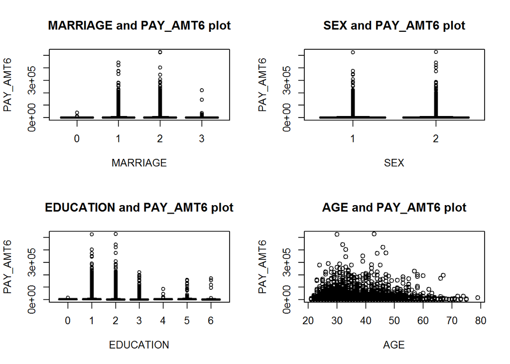

```r
par(mfrow = c(2,2))

plot(defaulters_data[,"MARRIAGE"],defaulters_data[,"PAY_AMT6"],xlab="MARRIAGE",ylab="PAY_AMT6",type="p",main="MARRIAGE and PAY_AMT6 plot" )
plot(defaulters_data[,"SEX"],defaulters_data[,"PAY_AMT6"],xlab="SEX",ylab="PAY_AMT6",type="p",main="SEX and PAY_AMT6 plot" )
plot(defaulters_data[,"EDUCATION"],defaulters_data[,"PAY_AMT6"],xlab="EDUCATION",ylab="PAY_AMT6",type="p",main="EDUCATION and PAY_AMT6 plot" )
plot(defaulters_data[,"AGE"],defaulters_data[,"PAY_AMT6"],xlab="AGE",ylab="PAY_AMT6",type="p",main="AGE and PAY_AMT6 plot" )
```

- Verify the corelation between the attributes

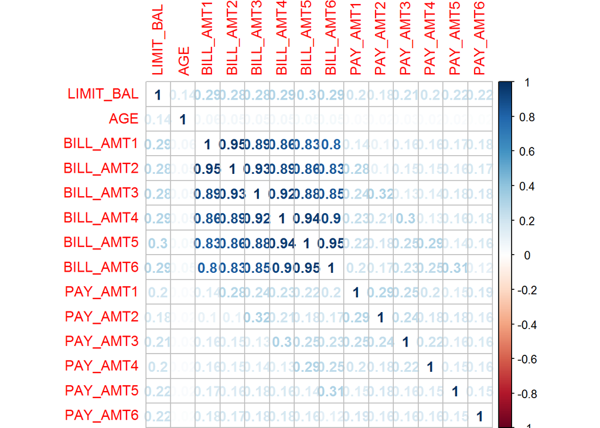

```r
library(corrplot)
num_var_new=setdiff(num_var,c("ï..ID"))
corrplot(cor(defaulters_data[,num_var_new]), method="number")
```

- check for class imbalance

```r
prop.table(table(defaulters_data$default.payment.next.month))
```

```
##
##      0      1
## 0.7788 0.2212
```

```r
library("ROSE")
defaulters_data <- ROSE(default.payment.next.month ~ ., data=defaulters_data, seed=111)$data
prop.table(table(defaulters_data$default.payment.next.month))
```

```
##
##         0         1
## 0.4993667 0.5006333
```

- Standardize the data

```r
library(vegan)
num_var_new=setdiff(num_var,c("ï..ID"))
defaulters_data[,num_var_new]=as.data.frame(apply(defaulters_data[,num_var_new],2,function(x) scale(x,center = T,scale = T)))
```

- PCA on numerical attributes since there is high corelation and many features

```r
defaulters_data_pca<-princomp(x = defaulters_data[,num_var_new],scores = T)
summary(defaulters_data_pca)
```

```
## Importance of components:
##                           Comp.1    Comp.2     Comp.3     Comp.4
## Standard deviation     2.2048240 1.2007263 1.01578649 0.97999114
## Proportion of Variance 0.3472436 0.1029851 0.07370404 0.06860105
## Cumulative Proportion  0.3472436 0.4502287 0.52393279 0.59253384
##                            Comp.5     Comp.6     Comp.7     Comp.8
## Standard deviation     0.94903029 0.93909693 0.93373463 0.91316070
## Proportion of Variance 0.06433489 0.06299517 0.06227782 0.05956359
## Cumulative Proportion  0.65686873 0.71986390 0.78214172 0.84170531
##                            Comp.9    Comp.10    Comp.11    Comp.12
## Standard deviation     0.87532712 0.64503871 0.52661433 0.50768827
## Proportion of Variance 0.05473022 0.02972063 0.01980942 0.01841114
## Cumulative Proportion  0.89643553 0.92615616 0.94596558 0.96437672
##                           Comp.13    Comp.14
## Standard deviation     0.50271958 0.49596602
## Proportion of Variance 0.01805253 0.01757075
## Cumulative Proportion  0.98242925 1.00000000
```

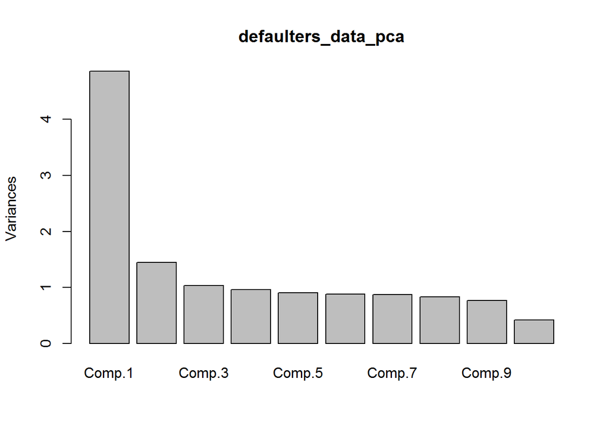

```r
plot(defaulters_data_pca)
```

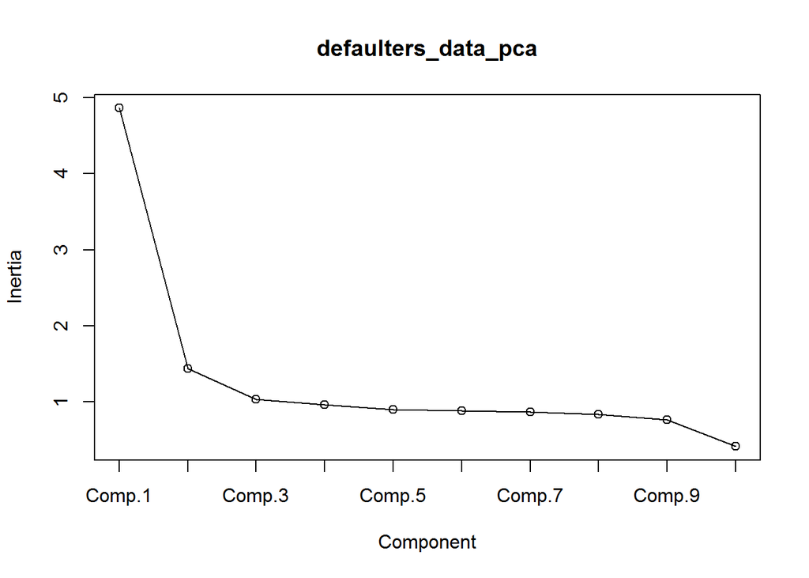

```r
screeplot(defaulters_data_pca,type= "lines")
```

```r
defaulters_data=cbind(defaulters_data_pca$scores,defaulters_data[,cat_var])
names(defaulters_data)
```

```
##  [1] "Comp.1"                     "Comp.2"
##  [3] "Comp.3"                     "Comp.4"
##  [5] "Comp.5"                     "Comp.6"
##  [7] "Comp.7"                     "Comp.8"
##  [9] "Comp.9"                     "Comp.10"
## [11] "Comp.11"                    "Comp.12"
## [13] "Comp.13"                    "Comp.14"
## [15] "SEX"                        "EDUCATION"
## [17] "MARRIAGE"                   "PAY_0"
## [19] "PAY_2"                      "PAY_3"
## [21] "PAY_4"                      "PAY_5"
## [23] "PAY_6"                      "default.payment.next.month"
```

We see that 89.6% of the total variance in the features is explained by the first 9 principal components. Hence, we choose first 9 components for the model.

```r
defaulters_data<-defaulters_data[,-c(10:14)]
names(defaulters_data)
```

```
##  [1] "Comp.1"                     "Comp.2"
##  [3] "Comp.3"                     "Comp.4"
##  [5] "Comp.5"                     "Comp.6"
##  [7] "Comp.7"                     "Comp.8"
##  [9] "Comp.9"                     "SEX"
## [11] "EDUCATION"                  "MARRIAGE"
## [13] "PAY_0"                      "PAY_2"
## [15] "PAY_3"                      "PAY_4"
## [17] "PAY_5"                      "PAY_6"
## [19] "default.payment.next.month"
```

## Train/Test Split

- Split the data 70/30 into train and test sets, using **Stratified Sampling** by setting the seed as “111”

```r
set.seed(111)
library(caret)
train_rows <- createDataPartition(defaulters_data$default.payment.next.month, p = 0.7, list = F)
trainP_data <- defaulters_data[train_rows, ]
testP_data <- defaulters_data[-train_rows, ]
summary(trainP_data)
```

```
##      Comp.1              Comp.2             Comp.3
##  Min.   :-22.50338   Min.   :-3.98667   Min.   :-17.167207
##  1st Qu.: -0.47439   1st Qu.:-0.65557   1st Qu.: -0.724375
##  Median :  0.67717   Median :-0.18654   Median : -0.064284
##  Mean   : -0.01129   Mean   : 0.00062   Mean   : -0.001371
##  3rd Qu.:  1.28711   3rd Qu.: 0.39529   3rd Qu.:  0.666765
##  Max.   :  3.26634   Max.   :39.71350   Max.   :  4.826528
##
##      Comp.4              Comp.5               Comp.6
##  Min.   :-22.54147   Min.   :-12.321500   Min.   :-16.167471
##  1st Qu.: -0.34979   1st Qu.: -0.365093   1st Qu.: -0.361843
##  Median :  0.02287   Median : -0.006612   Median : -0.002614
##  Mean   : -0.00240   Mean   :  0.003983   Mean   : -0.004137
##  3rd Qu.:  0.40009   3rd Qu.:  0.333769   3rd Qu.:  0.356195
##  Max.   : 33.50893   Max.   : 22.171562   Max.   : 19.886341
##
##      Comp.7               Comp.8              Comp.9          SEX
##  Min.   :-30.234330   Min.   :-20.44195   Min.   :-7.722308   1: 8570
##  1st Qu.: -0.374152   1st Qu.: -0.32733   1st Qu.:-0.567885   2:12431
##  Median : -0.004870   Median :  0.01793   Median :-0.036592
##  Mean   :  0.002285   Mean   : -0.00258   Mean   : 0.002906
##  3rd Qu.:  0.357645   3rd Qu.:  0.34904   3rd Qu.: 0.527401
##  Max.   : 15.820619   Max.   : 43.62033   Max.   : 4.082266
##
##  EDUCATION MARRIAGE      PAY_0          PAY_2          PAY_3
##  0:    9   0:   40   0      :8799   0      :9919   0      :10163
##  1: 7020   1: 9731   -1     :3600   2      :4287   2      : 4026
##  2:10188   2:11006   2      :3240   -1     :3765   -1     : 3688
##  3: 3536   3:  224   1      :3115   -2     :2480   -2     : 2692
##  4:   64             -2     :1679   3      : 372   3      :  260
##  5:  147             3      : 420   4      :  89   4      :   89
##  6:   37             (Other): 148   (Other):  89   (Other):   83
##      PAY_4           PAY_5           PAY_6
##  0      :10766   0      :11200   0      :10742
##  -1     : 3610   -1     : 3528   -1     : 3707
##  2      : 3322   -2     : 3061   -2     : 3343
##  -2     : 2911   2      : 2798   2      : 2816
##  3      :  197   3      :  200   3      :  226
##  7      :   79   4      :  106   7      :   69
##  (Other):  116   (Other):  108   (Other):   98
##  default.payment.next.month
##  0:10487
##  1:10514
##
##
##
##
##
```

```r
summary(testP_data)
```

```
##      Comp.1              Comp.2              Comp.3
##  Min.   :-19.02221   Min.   :-3.949174   Min.   :-4.645667
##  1st Qu.: -0.41741   1st Qu.:-0.640707   1st Qu.:-0.726899
##  Median :  0.67719   Median :-0.167628   Median :-0.059323
##  Mean   :  0.02634   Mean   :-0.001447   Mean   : 0.003199
##  3rd Qu.:  1.29767   3rd Qu.: 0.395959   3rd Qu.: 0.678042
##  Max.   :  2.97086   Max.   :25.118687   Max.   : 4.327039
##
##      Comp.4               Comp.5               Comp.6
##  Min.   :-16.002695   Min.   :-11.627391   Min.   :-9.237731
##  1st Qu.: -0.350514   1st Qu.: -0.372820   1st Qu.:-0.351873
##  Median :  0.025646   Median : -0.029527   Median : 0.006527
##  Mean   :  0.005612   Mean   : -0.009295   Mean   : 0.009654
##  3rd Qu.:  0.403369   3rd Qu.:  0.319064   3rd Qu.: 0.357243
##  Max.   : 12.203583   Max.   : 16.917005   Max.   :19.746155
##
##      Comp.7              Comp.8              Comp.9          SEX
##  Min.   :-9.271153   Min.   :-19.43884   Min.   :-8.456501   1:3801
##  1st Qu.:-0.380238   1st Qu.: -0.31165   1st Qu.:-0.571785   2:5198
##  Median :-0.014052   Median :  0.03109   Median :-0.049989
##  Mean   :-0.005333   Mean   :  0.00603   Mean   :-0.006782
##  3rd Qu.: 0.345039   3rd Qu.:  0.36735   3rd Qu.: 0.522101
##  Max.   :10.279810   Max.   :  8.82928   Max.   : 3.604196
##
##  EDUCATION MARRIAGE     PAY_0          PAY_2          PAY_3
##  0:   1    0:  10   0      :3738   0      :4217   0      :4320
##  1:2949    1:4179   -1     :1568   2      :1834   2      :1703
##  2:4381    2:4714   2      :1423   -1     :1654   -1     :1634
##  3:1565    3:  96   1      :1331   -2     :1065   -2     :1162
##  4:  24             -2     : 697   3      : 145   3      : 102
##  5:  66             3      : 174   4      :  44   4      :  34
##  6:  13             (Other):  68   (Other):  40   (Other):  44
##      PAY_4          PAY_5          PAY_6      default.payment.next.month
##  0      :4558   0      :4746   0      :4551   0:4494
##  -1     :1531   -1     :1473   -1     :1545   1:4505
##  2      :1454   -2     :1396   -2     :1499
##  -2     :1274   2      :1187   2      :1199
##  3      :  78   3      :  83   3      : 122
##  4      :  40   4      :  61   4      :  32
##  (Other):  64   (Other):  53   (Other):  51
```

```r
str(testP_data)
```

```
## 'data.frame':    8999 obs. of  19 variables:
##  $ Comp.1                    : num  0.5375 -0.0638 -0.2386 0.8874 1.2657 ...
##  $ Comp.2                    : num  0.465 -0.212 -0.74 -0.002 0.176 ...
##  $ Comp.3                    : num  2.039 -0.625 -0.423 0.579 -0.601 ...
##  $ Comp.4                    : num  0.196 -0.0124 -0.6677 0.3118 -0.2701 ...
##  $ Comp.5                    : num  0.0996 0.6806 -0.4747 0.5189 0.6563 ...
##  $ Comp.6                    : num  -0.0817 -0.089 -0.5851 -0.416 0.3615 ...
##  $ Comp.7                    : num  0.554 0.416 -0.191 -1.021 1.391 ...
##  $ Comp.8                    : num  0.4487 -0.0361 0.5924 -0.6333 0.3355 ...
##  $ Comp.9                    : num  0.1598 -0.4146 0.0514 0.5251 0.1006 ...
##  $ SEX                       : Factor w/ 2 levels "1","2": 2 2 2 2 2 2 2 2 2 2 ...
##  $ EDUCATION                 : Factor w/ 7 levels "0","1","2","3",..: 2 2 3 3 3 3 2 4 2 2 ...
##  $ MARRIAGE                  : Factor w/ 4 levels "0","1","2","3": 2 3 3 2 2 3 3 2 2 3 ...
##  $ PAY_0                     : Factor w/ 11 levels "-1","-2","0",..: 1 3 4 2 3 4 1 3 2 3 ...
##  $ PAY_2                     : Factor w/ 11 levels "-1","-2","0",..: 1 3 5 2 1 2 1 3 2 3 ...
##  $ PAY_3                     : Factor w/ 11 levels "-1","-2","0",..: 2 3 5 2 1 1 1 3 2 3 ...
##  $ PAY_4                     : Factor w/ 11 levels "-1","-2","0",..: 2 3 5 2 1 1 1 3 2 3 ...
##  $ PAY_5                     : Factor w/ 10 levels "-1","-2","0",..: 2 3 4 2 1 1 1 3 2 3 ...
##  $ PAY_6                     : Factor w/ 10 levels "-1","-2","0",..: 2 3 4 2 1 1 1 3 2 3 ...
##  $ default.payment.next.month: Factor w/ 2 levels "0","1": 1 1 1 1 1 1 1 1 1 1 ...
```

```r
prop.table(table(trainP_data$default.payment.next.month))
```

```
##
##         0         1
## 0.4993572 0.5006428
```

```r
prop.table(table(testP_data$default.payment.next.month))
```

```
##
##         0         1
## 0.4993888 0.5006112
```

# Building a model

## Logistic Regression Model

```r
log_model = glm(default.payment.next.month~., data =trainP_data, family = binomial)

library(e1071)
nb_model <- naiveBayes(default.payment.next.month~.,data = trainP_data)
```

- summary of the model

```r
summary(log_model)
```

```
##
## Call:
## glm(formula = default.payment.next.month ~ ., family = binomial,
##     data = trainP_data)
##
## Deviance Residuals:
##      Min        1Q    Median        3Q       Max
## -2.73185  -0.93340   0.00164   1.03659   2.40314
##
## Coefficients:
##               Estimate Std. Error z value Pr(>|z|)
## (Intercept) -1.476e+01  1.757e+02  -0.084 0.933048
## Comp.1       2.938e-02  8.260e-03   3.556 0.000376 ***
## Comp.2      -1.972e-01  1.663e-02 -11.858  < 2e-16 ***
## Comp.3      -5.837e-03  1.778e-02  -0.328 0.742671
## Comp.4      -1.259e-02  1.867e-02  -0.674 0.500167
## Comp.5       2.537e-02  1.734e-02   1.463 0.143388
## Comp.6      -4.824e-04  1.818e-02  -0.027 0.978830
## Comp.7       1.677e-02  1.886e-02   0.890 0.373726
## Comp.8       2.166e-02  2.075e-02   1.044 0.296593
## Comp.9      -1.201e-01  1.948e-02  -6.165 7.03e-10 ***
## SEX2        -1.312e-01  3.219e-02  -4.075 4.61e-05 ***
## EDUCATION1   1.318e+01  1.757e+02   0.075 0.940180
## EDUCATION2   1.328e+01  1.757e+02   0.076 0.939721
## EDUCATION3   1.323e+01  1.757e+02   0.075 0.939968
## EDUCATION4   1.253e+01  1.757e+02   0.071 0.943133
## EDUCATION5   1.186e+01  1.757e+02   0.068 0.946172
## EDUCATION6   1.260e+01  1.757e+02   0.072 0.942834
## MARRIAGE1    1.364e+00  4.229e-01   3.226 0.001255 **
## MARRIAGE2    1.208e+00  4.233e-01   2.855 0.004310 **
## MARRIAGE3    1.600e+00  4.489e-01   3.565 0.000364 ***
## PAY_0-2     -5.780e-01  1.055e-01  -5.478 4.30e-08 ***
## PAY_00      -5.197e-01  7.801e-02  -6.662 2.71e-11 ***
## PAY_01       2.741e-01  7.450e-02   3.680 0.000234 ***
## PAY_02       1.724e+00  8.310e-02  20.743  < 2e-16 ***
## PAY_03       1.633e+00  2.053e-01   7.954 1.80e-15 ***
## PAY_04       3.991e-01  3.344e-01   1.193 0.232713
## PAY_05       1.176e+00  5.922e-01   1.986 0.047083 *
## PAY_06      -5.315e-01  1.037e+00  -0.512 0.608385
## PAY_07      -1.133e+01  2.674e+02  -0.042 0.966203
```

[output cut: 41 more lines]

```
## PAY_64       2.601e-01  5.647e-01   0.461 0.645018
## PAY_65      -7.275e-01  9.075e-01  -0.802 0.422744
## PAY_66      -1.617e-01  9.809e-01  -0.165 0.869067
## PAY_67      -1.038e+01  2.176e+02  -0.048 0.961969
## PAY_68       1.369e+01  9.231e+02   0.015 0.988166
## ---
## Signif. codes:  0 '***' 0.001 '**' 0.01 '*' 0.05 '.' 0.1 ' ' 1
##
## (Dispersion parameter for binomial family taken to be 1)
##
##     Null deviance: 29114  on 21000  degrees of freedom
## Residual deviance: 24007  on 20926  degrees of freedom
## AIC: 24157
##
## Number of Fisher Scoring iterations: 12
```

- Improving the model using stepAIC.

```r
library(MASS)
log_model_step = stepAIC(log_model)
```

```
## Start:  AIC=24156.58
## default.payment.next.month ~ Comp.1 + Comp.2 + Comp.3 + Comp.4 +
##     Comp.5 + Comp.6 + Comp.7 + Comp.8 + Comp.9 + SEX + EDUCATION +
##     MARRIAGE + PAY_0 + PAY_2 + PAY_3 + PAY_4 + PAY_5 + PAY_6
```

```
##             Df Deviance   AIC
## - Comp.6     1    24007 24155
## - Comp.3     1    24007 24155
## - Comp.4     1    24007 24155
## - Comp.7     1    24007 24155
## - Comp.8     1    24008 24156
## <none>            24007 24157
## - Comp.5     1    24009 24157
## - PAY_2     10    24032 24162
## - PAY_5      8    24031 24165
## - Comp.1     1    24019 24167
## - SEX        1    24023 24171
## - PAY_3      9    24052 24184
## - MARRIAGE   3    24041 24185
## - Comp.9     1    24045 24193
## - PAY_4      9    24063 24195
## - PAY_6      9    24077 24209
## - EDUCATION  6    24073 24211
## - Comp.2     1    24164 24312
## - PAY_0     10    25391 25521
##
## Step:  AIC=24154.58
## default.payment.next.month ~ Comp.1 + Comp.2 + Comp.3 + Comp.4 +
##     Comp.5 + Comp.7 + Comp.8 + Comp.9 + SEX + EDUCATION + MARRIAGE +
##     PAY_0 + PAY_2 + PAY_3 + PAY_4 + PAY_5 + PAY_6
```

```
##             Df Deviance   AIC
## - Comp.3     1    24007 24153
## - Comp.4     1    24007 24153
## - Comp.7     1    24007 24153
## - Comp.8     1    24008 24154
## <none>            24007 24155
## - Comp.5     1    24009 24155
## - PAY_2     10    24032 24160
## - PAY_5      8    24032 24164
## - Comp.1     1    24019 24165
## - SEX        1    24023 24169
## - PAY_3      9    24052 24182
## - MARRIAGE   3    24041 24183
## - Comp.9     1    24045 24191
## - PAY_4      9    24063 24193
## - PAY_6      9    24077 24207
## - EDUCATION  6    24073 24209
## - Comp.2     1    24164 24310
## - PAY_0     10    25391 25519
##
## Step:  AIC=24152.69
## default.payment.next.month ~ Comp.1 + Comp.2 + Comp.4 + Comp.5 +
##     Comp.7 + Comp.8 + Comp.9 + SEX + EDUCATION + MARRIAGE + PAY_0 +
##     PAY_2 + PAY_3 + PAY_4 + PAY_5 + PAY_6
```

```
##             Df Deviance   AIC
## - Comp.4     1    24007 24151
## - Comp.7     1    24008 24152
## - Comp.8     1    24008 24152
## <none>            24007 24153
## - Comp.5     1    24009 24153
## - PAY_2     10    24032 24158
## - PAY_5      8    24032 24162
## - Comp.1     1    24020 24164
## - SEX        1    24023 24167
## - PAY_3      9    24052 24180
## - MARRIAGE   3    24043 24183
## - Comp.9     1    24045 24189
## - PAY_4      9    24064 24192
## - PAY_6      9    24077 24205
## - EDUCATION  6    24073 24207
## - Comp.2     1    24164 24308
## - PAY_0     10    25391 25517
##
## Step:  AIC=24151.17
## default.payment.next.month ~ Comp.1 + Comp.2 + Comp.5 + Comp.7 +
##     Comp.8 + Comp.9 + SEX + EDUCATION + MARRIAGE + PAY_0 + PAY_2 +
##     PAY_3 + PAY_4 + PAY_5 + PAY_6
```

```
##             Df Deviance   AIC
## - Comp.7     1    24008 24150
## - Comp.8     1    24008 24150
## <none>            24007 24151
## - Comp.5     1    24009 24151
## - PAY_2     10    24033 24157
## - PAY_5      8    24032 24160
## - Comp.1     1    24020 24162
## - SEX        1    24024 24166
## - PAY_3      9    24053 24179
## - MARRIAGE   3    24043 24181
## - Comp.9     1    24046 24188
## - PAY_4      9    24064 24190
## - PAY_6      9    24078 24204
## - EDUCATION  6    24073 24205
## - Comp.2     1    24164 24306
## - PAY_0     10    25392 25516
##
## Step:  AIC=24149.89
## default.payment.next.month ~ Comp.1 + Comp.2 + Comp.5 + Comp.8 +
##     Comp.9 + SEX + EDUCATION + MARRIAGE + PAY_0 + PAY_2 + PAY_3 +
##     PAY_4 + PAY_5 + PAY_6
```

```
##             Df Deviance   AIC
## - Comp.8     1    24009 24149
## <none>            24008 24150
## - Comp.5     1    24010 24150
## - PAY_2     10    24034 24156
## - PAY_5      8    24033 24159
## - Comp.1     1    24021 24161
## - SEX        1    24024 24164
## - PAY_3      9    24054 24178
## - MARRIAGE   3    24044 24180
## - Comp.9     1    24046 24186
## - PAY_4      9    24064 24188
## - PAY_6      9    24079 24203
## - EDUCATION  6    24074 24204
## - Comp.2     1    24164 24304
## - PAY_0     10    25393 25515
##
## Step:  AIC=24149.27
## default.payment.next.month ~ Comp.1 + Comp.2 + Comp.5 + Comp.9 +
##     SEX + EDUCATION + MARRIAGE + PAY_0 + PAY_2 + PAY_3 + PAY_4 +
##     PAY_5 + PAY_6
```

```
##             Df Deviance   AIC
## <none>            24009 24149
## - Comp.5     1    24011 24149
## - PAY_2     10    24036 24156
## - PAY_5      8    24035 24159
## - Comp.1     1    24022 24160
## - SEX        1    24025 24163
## - PAY_3      9    24054 24176
## - MARRIAGE   3    24045 24179
## - Comp.9     1    24047 24185
## - PAY_4      9    24066 24188
## - PAY_6      9    24080 24202
## - EDUCATION  6    24076 24204
## - Comp.2     1    24166 24304
## - PAY_0     10    25396 25516
```

```r
#stepAIC improves the AIC value
```

*find any multi-collinearity

```r
library(car)
log_model_vif = vif(log_model)
log_model_vif
```

```
##                   GVIF Df GVIF^(1/(2*Df))
## Comp.1    1.276000e+00  1        1.129602
## Comp.2    1.261839e+00  1        1.123316
## Comp.3    1.286883e+00  1        1.134409
## Comp.4    1.080911e+00  1        1.039669
## Comp.5    1.039308e+00  1        1.019464
## Comp.6    1.043411e+00  1        1.021475
## Comp.7    1.054227e+00  1        1.026756
## Comp.8    1.058813e+00  1        1.028986
## Comp.9    1.177297e+00  1        1.085033
## SEX       1.028628e+00  1        1.014213
## EDUCATION 1.233974e+00  6        1.017674
## MARRIAGE  1.281197e+00  3        1.042164
## PAY_0     1.902058e+12 10        4.111130
## PAY_2     9.471737e+13 10        4.998290
## PAY_3     2.438251e+13  9        5.542766
## PAY_4     3.251021e+09  9        3.376335
## PAY_5     1.049857e+09  8        3.662863
## PAY_6     3.280534e+07  9        2.615486
```

```r
log_model_step_vif = vif(log_model_step)
log_model_step_vif
```

```
##                   GVIF Df GVIF^(1/(2*Df))
## Comp.1    1.262585e+00  1        1.123648
## Comp.2    1.240522e+00  1        1.113787
## Comp.5    1.033490e+00  1        1.016607
## Comp.9    1.175871e+00  1        1.084376
## SEX       1.019283e+00  1        1.009595
## EDUCATION 1.198586e+00  6        1.015210
## MARRIAGE  1.086108e+00  3        1.013862
## PAY_0     1.881793e+12 10        4.108929
## PAY_2     9.221136e+13 10        4.991594
## PAY_3     2.365253e+13  9        5.533415
## PAY_4     3.142410e+09  9        3.369968
## PAY_5     1.005812e+09  8        3.653064
## PAY_6     3.207334e+07  9        2.612210
```

- Check the model summary to check for any insignificant variables

```r
summary(log_model_step)
```

```
##
## Call:
## glm(formula = default.payment.next.month ~ Comp.1 + Comp.2 +
##     Comp.5 + Comp.9 + SEX + EDUCATION + MARRIAGE + PAY_0 + PAY_2 +
##     PAY_3 + PAY_4 + PAY_5 + PAY_6, family = binomial, data = trainP_data)
##
## Deviance Residuals:
##      Min        1Q    Median        3Q       Max
## -2.72201  -0.93397   0.00164   1.03730   2.42958
##
## Coefficients:
##               Estimate Std. Error z value Pr(>|z|)
## (Intercept) -1.476e+01  1.758e+02  -0.084 0.933060
## Comp.1       2.910e-02  8.215e-03   3.542 0.000396 ***
## Comp.2      -1.967e-01  1.653e-02 -11.900  < 2e-16 ***
## Comp.5       2.510e-02  1.740e-02   1.442 0.149248
## Comp.9      -1.203e-01  1.949e-02  -6.172 6.73e-10 ***
## SEX2        -1.287e-01  3.204e-02  -4.017 5.90e-05 ***
## EDUCATION1   1.319e+01  1.758e+02   0.075 0.940194
## EDUCATION2   1.329e+01  1.758e+02   0.076 0.939734
## EDUCATION3   1.323e+01  1.758e+02   0.075 0.940008
## EDUCATION4   1.254e+01  1.758e+02   0.071 0.943143
## EDUCATION5   1.187e+01  1.758e+02   0.068 0.946173
## EDUCATION6   1.259e+01  1.758e+02   0.072 0.942914
## MARRIAGE1    1.362e+00  4.220e-01   3.227 0.001250 **
## MARRIAGE2    1.213e+00  4.223e-01   2.872 0.004084 **
## MARRIAGE3    1.591e+00  4.480e-01   3.551 0.000384 ***
## PAY_0-2     -5.790e-01  1.054e-01  -5.493 3.96e-08 ***
## PAY_00      -5.217e-01  7.794e-02  -6.694 2.17e-11 ***
## PAY_01       2.725e-01  7.443e-02   3.661 0.000251 ***
## PAY_02       1.723e+00  8.305e-02  20.741  < 2e-16 ***
## PAY_03       1.633e+00  2.053e-01   7.954 1.81e-15 ***
## PAY_04       4.042e-01  3.345e-01   1.209 0.226831
## PAY_05       1.196e+00  5.936e-01   2.015 0.043954 *
## PAY_06      -5.316e-01  1.037e+00  -0.513 0.608194
## PAY_07      -1.132e+01  2.673e+02  -0.042 0.966208
## PAY_08      -1.122e+01  3.091e+02  -0.036 0.971034
## PAY_2-2      2.285e-01  1.151e-01   1.985 0.047134 *
## PAY_20       8.268e-02  9.096e-02   0.909 0.363322
## PAY_21       5.565e-02  4.641e-01   0.120 0.904558
```

[output cut: 37 more lines]

```
## PAY_64       2.578e-01  5.643e-01   0.457 0.647864
## PAY_65      -7.338e-01  9.072e-01  -0.809 0.418588
## PAY_66      -1.647e-01  9.815e-01  -0.168 0.866761
## PAY_67      -1.038e+01  2.175e+02  -0.048 0.961930
## PAY_68       1.366e+01  9.232e+02   0.015 0.988198
## ---
## Signif. codes:  0 '***' 0.001 '**' 0.01 '*' 0.05 '.' 0.1 ' ' 1
##
## (Dispersion parameter for binomial family taken to be 1)
##
##     Null deviance: 29114  on 21000  degrees of freedom
## Residual deviance: 24009  on 20931  degrees of freedom
## AIC: 24149
##
## Number of Fisher Scoring iterations: 12
```

```r
#Since AIC value is less, we choose 'log_model_step' as our final model
```

## Creating an ROC Curve

1. predictions (probability scores) using the predict() function

```r
prob_train_model <- predict(log_model, type = "response")
prob_train_step <- predict(log_model_step, type = "response")
```

2)creating a “prediction()” object using ROCR curve

```r
library(ROCR)
pred_model <- prediction(prob_train_model, trainP_data$default.payment.next.month)
pred_step <- prediction(prob_train_step, trainP_data$default.payment.next.month)
```

3. Extracting performance measures (True Positive Rate and False Positive Rate) using the “performance()” function from the ROCR package

```r
perf_model <- performance(pred_model, measure="tpr", x.measure="fpr")
perf_model_step <- performance(pred_step, measure="tpr", x.measure="fpr")
```

4. Plotting the ROC curve using the extracted performance measures (TPR and FPR)

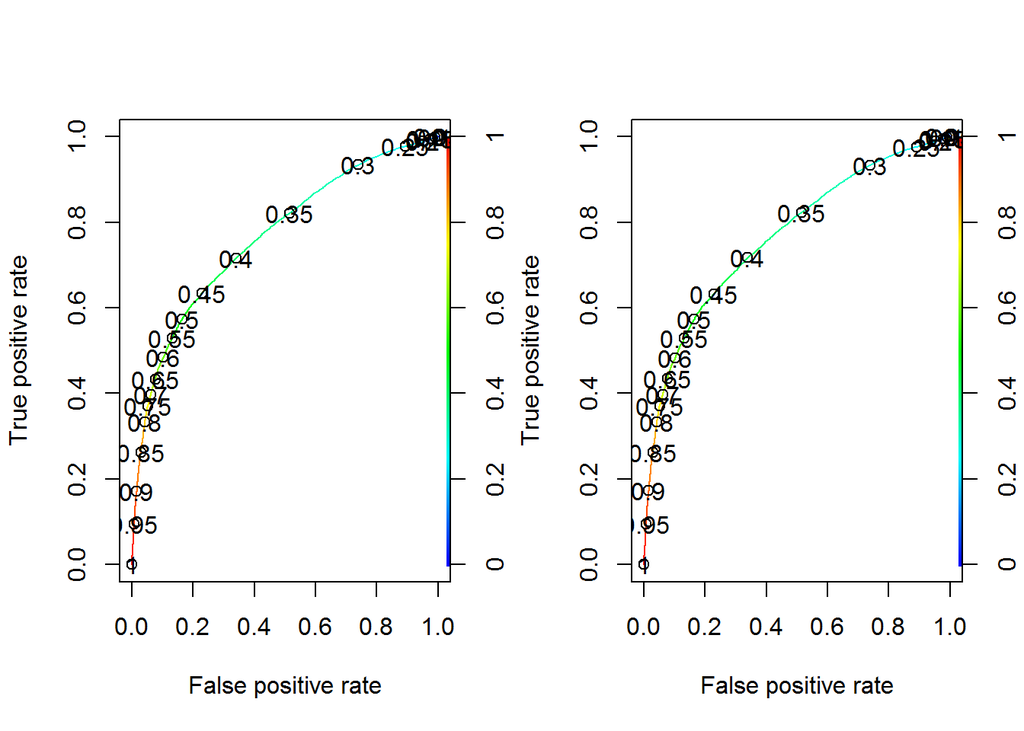

```r
par(mfrow = c(1,2))
plot(perf_model, col=rainbow(10), colorize=T, print.cutoffs.at=seq(0,1,0.05))
plot(perf_model_step, col=rainbow(10), colorize=T, print.cutoffs.at=seq(0,1,0.05))
```

- Extracting the AUC score of the ROC curve and store it in a variable named “auc”

```r
perf_auc_model <- performance(pred_model, measure="auc")

auc_model <- perf_auc_model@y.values[[1]]

print(auc_model)
```

```
## [1] 0.7665279
```

```r
perf_auc_step <- performance(pred_step, measure="auc")

auc_step <- perf_auc_step@y.values[[1]]

print(auc_step)
```

```
## [1] 0.7666436
```

## Choosing a Cutoff Value

- Based on the trade off between TPR and FPR depending on the business domain, a call on the cutoff is made.

```r
pred_class_model <- ifelse(prob_train_model> 0.35,"1","0")
table(trainP_data$default.payment.next.month,pred_class_model)
```

```
##    pred_class_model
##        0    1
##   0 5078 5409
##   1 1878 8636
```

```r
# A cutoff of 0.35 seems reasonable

pred_class_step <- ifelse(prob_train_step> 0.35,"1","0")
table(trainP_data$default.payment.next.month,pred_class_step)
```

```
##    pred_class_step
##        0    1
##   0 5094 5393
##   1 1861 8653
```

## Predictions on test data

- After choosing a cutoff value, predicting the class labels on the test data using our glm and stepaic model

```r
prob_test_model <- predict(log_model, testP_data, type = "response")

preds_test_model <- ifelse(prob_test_model > 0.35,"1","0")

confm_model= table(testP_data$default.payment.next.month,preds_test_model)
confm_model
```

```
##    preds_test_model
##        0    1
##   0 2130 2364
##   1  753 3752
```

```r
prob_test_step <- predict(log_model_step, testP_data, type = "response")

preds_test_step <- ifelse(prob_test_step > 0.35,"1","0")

confm_model_step= table(testP_data$default.payment.next.month,preds_test_step)
confm_model_step
```

```
##    preds_test_step
##        0    1
##   0 2127 2367
##   1  750 3755
```

```r
pred_nb <- predict(nb_model, testP_data)
confm_model_nb = table(testP_data$default.payment.next.month,pred_nb)
```

# Evaluation Metrics for classification

## Automated Computation through Caret

- Using the caret package to compute the evaluation metrics

```r
library(e1071)
conf_model = confusionMatrix(preds_test_model, testP_data$default.payment.next.month, positive = "1")
conf_model
```

```
## Confusion Matrix and Statistics
##
##           Reference
## Prediction    0    1
##          0 2130  753
##          1 2364 3752
##
##                Accuracy : 0.6536
##                  95% CI : (0.6437, 0.6635)
##     No Information Rate : 0.5006
##     P-Value [Acc > NIR] : < 2.2e-16
##
##                   Kappa : 0.307
##  Mcnemar's Test P-Value : < 2.2e-16
##
##             Sensitivity : 0.8329
##             Specificity : 0.4740
##          Pos Pred Value : 0.6135
##          Neg Pred Value : 0.7388
##              Prevalence : 0.5006
##          Detection Rate : 0.4169
##    Detection Prevalence : 0.6796
##       Balanced Accuracy : 0.6534
##
##        'Positive' Class : 1
##
```

```r
conf_step = confusionMatrix(preds_test_step, testP_data$default.payment.next.month, positive = "1")
conf_step
```

```
## Confusion Matrix and Statistics
##
##           Reference
## Prediction    0    1
##          0 2127  750
##          1 2367 3755
##
##                Accuracy : 0.6536
##                  95% CI : (0.6437, 0.6635)
##     No Information Rate : 0.5006
##     P-Value [Acc > NIR] : < 2.2e-16
##
##                   Kappa : 0.307
##  Mcnemar's Test P-Value : < 2.2e-16
##
##             Sensitivity : 0.8335
##             Specificity : 0.4733
##          Pos Pred Value : 0.6134
##          Neg Pred Value : 0.7393
##              Prevalence : 0.5006
##          Detection Rate : 0.4173
##    Detection Prevalence : 0.6803
##       Balanced Accuracy : 0.6534
##
##        'Positive' Class : 1
##
```

```r
conf_nb = confusionMatrix(pred_nb, testP_data$default.payment.next.month, positive = "1")
conf_nb
```

```
## Confusion Matrix and Statistics
##
##           Reference
## Prediction    0    1
##          0 2690  707
##          1 1804 3798
##
##                Accuracy : 0.721
##                  95% CI : (0.7116, 0.7302)
##     No Information Rate : 0.5006
##     P-Value [Acc > NIR] : < 2.2e-16
##
##                   Kappa : 0.4418
##  Mcnemar's Test P-Value : < 2.2e-16
##
##             Sensitivity : 0.8431
##             Specificity : 0.5986
##          Pos Pred Value : 0.6780
##          Neg Pred Value : 0.7919
##              Prevalence : 0.5006
##          Detection Rate : 0.4220
##    Detection Prevalence : 0.6225
##       Balanced Accuracy : 0.7208
##
##        'Positive' Class : 1
##
```

# Finding the F1 score since it is very important to have high precision and recall for this problem

# Print F1 score

```r
F1_score<-function(Recall, Precision)   {
     F1<-2*Recall*Precision/(Recall+Precision)
     return(F1)
}

recall_model_step =  confm_model_step[2, 2]/sum(confm_model_step[2, ])
recall_model =  confm_model[2, 2]/sum(confm_model[2, ])
recall_model_nb =  confm_model_nb[2, 2]/sum(confm_model_nb[2, ])


precision_model_step =  confm_model_step[2, 2]/sum(confm_model_step[,2 ])
precision_model =  confm_model[2, 2]/sum(confm_model[,2 ])
precision_model_nb =  confm_model_nb[2, 2]/sum(confm_model_nb[,2 ])


F1_model_step<-F1_score(recall_model_step,precision_model_step)
F1_model<-F1_score(recall_model,precision_model)
F1_model_nb<-F1_score(recall_model_nb,precision_model_nb)

print(F1_model_step)
```

```
## [1] 0.7066905
```

```r
print(F1_model)
```

```
## [1] 0.7065248
```

```r
print(F1_model_nb)
```

```
## [1] 0.7515583
```